# Seminar 4: Differential Expression Analysis

Jennifer Grants

2/4/2019

# Dataset & design

```r
expressionMatrix <- read.table(file = "./data/GSE4051_data.tsv", sep = "\t", quote = "", stringsAsFactors = F)

expressionMatrix <- rownames_to_column(expressionMatrix, var = "gene")
expressionMatrix <- as.tibble(expressionMatrix)

expressionMatrix
```

```
## # A tibble: 29,949 x 40
##    gene  Sample_20 Sample_21 Sample_22 Sample_23 Sample_16 Sample_17
##    <chr>     <dbl>     <dbl>     <dbl>     <dbl>     <dbl>     <dbl>
##  1 1415~      7.24      7.41      7.17      7.07      7.38      7.34
##  2 1415~      9.48     10.0       9.85     10.1       7.64     10.0
##  3 1415~     10.0      10.0       9.91      9.91      8.42     10.2
##  4 1415~      8.36      8.37      8.40      8.49      8.36      8.37
##  5 1415~      8.59      8.62      8.52      8.64      8.51      8.89
##  6 1415~      9.59      9.72      9.71      9.7       9.66      9.61
##  7 1415~      9.68     10.4       9.87     10.2       8.04     10.0
##  8 1415~      7.24      7.90      7.48      7.49      7.34      7.34
##  9 1415~     11.7      11.5      11.5      11.6      10.5      11.8
## 10 1415~      9.21     10.1       9.82      9.92      8.22      9.60
## # ... with 29,939 more rows, and 33 more variables: Sample_6 <dbl>,
## #   Sample_24 <dbl>, Sample_25 <dbl>, Sample_26 <dbl>, Sample_27 <dbl>,
## #   Sample_14 <dbl>, Sample_3 <dbl>, Sample_5 <dbl>, Sample_8 <dbl>,
## #   Sample_28 <dbl>, Sample_29 <dbl>, Sample_30 <dbl>, Sample_31 <dbl>,
## #   Sample_1 <dbl>, Sample_10 <dbl>, Sample_4 <dbl>, Sample_7 <dbl>,
## #   Sample_32 <dbl>, Sample_33 <dbl>, Sample_34 <dbl>, Sample_35 <dbl>,
## #   Sample_13 <dbl>, Sample_15 <dbl>, Sample_18 <dbl>, Sample_19 <dbl>,
## #   Sample_36 <dbl>, Sample_37 <dbl>, Sample_38 <dbl>, Sample_39 <dbl>,
## #   Sample_11 <dbl>, Sample_12 <dbl>, Sample_2 <dbl>, Sample_9 <dbl>
```

```r
samplesMetadata <- read.table("./data/GSE4051_design.txt",  sep = "\t", header = TRUE, stringsAsFactors = FALSE)

samplesMetadata <- samplesMetadata %>% as_tibble()

# define our own column names for samples metadata for clarity
names(samplesMetadata) <- c("sample_id", "sample_number", "dev_stage", "genotype")

samplesMetadata
```

```
## # A tibble: 39 x 4
##    sample_id sample_number dev_stage genotype
##    <chr>             <int> <chr>     <chr>
##  1 Sample_20            20 E16       wt
##  2 Sample_21            21 E16       wt
##  3 Sample_22            22 E16       wt
##  4 Sample_23            23 E16       wt
##  5 Sample_16            16 E16       NrlKO
##  6 Sample_17            17 E16       NrlKO
##  7 Sample_6              6 E16       NrlKO
##  8 Sample_24            24 P2        wt
##  9 Sample_25            25 P2        wt
## 10 Sample_26            26 P2        wt
## # ... with 29 more rows
```

Convert `dev_stage` and `genotype` to factors:

```r
samplesMetadata$dev_stage <- factor(samplesMetadata$dev_stage, levels = c("E16", "P2", "P6", "P10", "4_weeks"))
samplesMetadata$genotype <- factor(samplesMetadata$genotype, levels = c("wt", "NrlKO"))
```

Check dimensions of expression and metadata:

```r
ncol(expressionMatrix)-1 # because "gene" is a column
```

```
## [1] 39
```

```r
nrow(samplesMetadata)
```

```
## [1] 39
```

Check that the sample names match:

```r
identical(colnames(expressionMatrix[,2:ncol(expressionMatrix)]), samplesMetadata$sample_id)
```

```
## [1] TRUE
```

# QC Plots

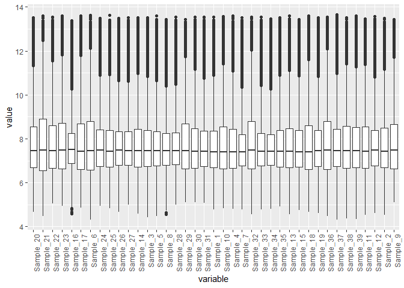

```r
meltedExpressionMatrix <- expressionMatrix %>% melt(id = "gene")

meltedExpressionMatrix %>%
  ggplot(aes(x = variable, y = value)) +
  geom_boxplot() +
  theme(axis.text.x = element_text(angle = 90, hjust = 1))
```

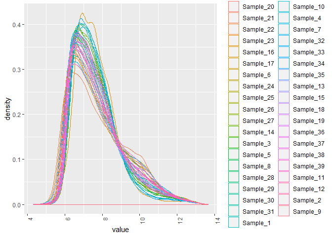

```r
meltedExpressionMatrix %>%
  ggplot(aes(x = value, color = variable)) +
  geom_density() +
  theme(axis.text.x = element_text(angle = 90, hjust = 1))
```

> Conclusion: The distribution of gene expression is similar across samples, as expected.

# Single gene approach

## Plot expression of 2 probes across 2 genotype groups

```r
geneIds <- c("1416119_at", "1431708_a_at")

# use dplyr::filter() to get the expression data for the gene
expressionDataForGene <- filter(meltedExpressionMatrix, gene %in% geneIds)

# reformat, change column titles, and join with metadata
expressionDataForGene <- select(expressionDataForGene, variable, gene, value) %>%
  rename(sample_id = variable, expression = value) %>%
  arrange(gene) %>%
  left_join(samplesMetadata, by = "sample_id")

expressionDataForGene
```

```
##    sample_id         gene expression sample_number dev_stage genotype
## 1  Sample_20   1416119_at     10.580            20       E16       wt
## 2  Sample_21   1416119_at     11.000            21       E16       wt
## 3  Sample_22   1416119_at     10.850            22       E16       wt
## 4  Sample_23   1416119_at     10.920            23       E16       wt
## 5  Sample_16   1416119_at      9.203            16       E16    NrlKO
## 6  Sample_17   1416119_at     11.010            17       E16    NrlKO
## 7   Sample_6   1416119_at     10.900             6       E16    NrlKO
## 8  Sample_24   1416119_at     10.380            24        P2       wt
## 9  Sample_25   1416119_at     10.610            25        P2       wt
## 10 Sample_26   1416119_at     10.250            26        P2       wt
## 11 Sample_27   1416119_at      9.745            27        P2       wt
## 12 Sample_14   1416119_at     10.660            14        P2    NrlKO
## 13  Sample_3   1416119_at     10.620             3        P2    NrlKO
## 14  Sample_5   1416119_at     10.200             5        P2    NrlKO
```

[output cut: 64 more lines]

Plot and assess whether probes appear differentially expressed:

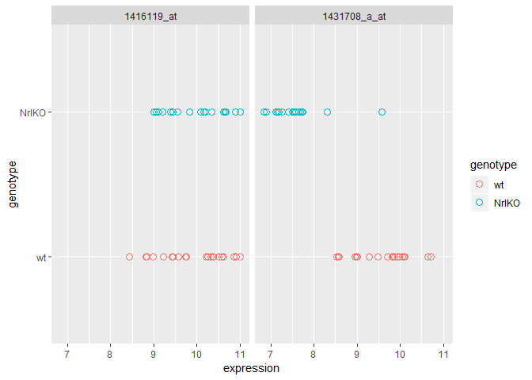

```r
expressionDataForGene %>%
  ggplot(aes(x = expression, y = genotype, color = genotype)) +
  geom_point(size = 3, shape = 1) +
  facet_wrap(~gene)
```

> Interim conclusion: Probe 1416119_at does not appear differentially expressed, and probe 1431708_a_at appears differentially expressed between wt and NrlKO.

## T-tests

Perform a t-test comparing expression of the probe 1416119_at in NrlKO vs. wt:

```r
boringGene <- filter(expressionDataForGene, gene == "1416119_at")

t.test(expression ~ genotype, data = boringGene)
```

```
##
##  Welch Two Sample t-test
##
## data:  expression by genotype
## t = -0.18395, df = 36.534, p-value = 0.8551
## alternative hypothesis: true difference in means is not equal to 0
## 95 percent confidence interval:
##  -0.5079125  0.4233967
## sample estimates:
##    mean in group wt mean in group NrlKO
##            9.892900            9.935158
```

> Conclusion: There is no significant difference in expression of 1416119_at between wt and NrlKO.

Perform a t-test comparing expression of the probe 1431708_a_at in NrlKO vs. wt:

```r
interestingGene <- filter(expressionDataForGene, gene == "1431708_a_at")

(t_interesting <- t.test(expression ~ genotype, data = interestingGene))
```

```
##
##  Welch Two Sample t-test
##
## data:  expression by genotype
## t = 9.838, df = 36.89, p-value = 7.381e-12
## alternative hypothesis: true difference in means is not equal to 0
## 95 percent confidence interval:
##  1.569556 2.383870
## sample estimates:
##    mean in group wt mean in group NrlKO
##            9.554450            7.577737
```

## Linear regressions

Perform linear regression comparing expression of the probe 1416119_at in NrlKO vs. wt:

```r
summary(lm(expression ~ genotype, boringGene))
```

```
##
## Call:
## lm(formula = expression ~ genotype, data = boringGene)
##
## Residuals:
##     Min      1Q  Median      3Q     Max
## -1.4559 -0.5257  0.1448  0.6460  1.1071
##
## Coefficients:
##               Estimate Std. Error t value Pr(>|t|)
## (Intercept)    9.89290    0.16104  61.432   <2e-16 ***
## genotypeNrlKO  0.04226    0.23072   0.183    0.856
## ---
## Signif. codes:  0 '***' 0.001 '**' 0.01 '*' 0.05 '.' 0.1 ' ' 1
##
## Residual standard error: 0.7202 on 37 degrees of freedom
## Multiple R-squared:  0.0009058,  Adjusted R-squared:  -0.0261
## F-statistic: 0.03355 on 1 and 37 DF,  p-value: 0.8557
```

> Conclusions: The p-value for genotypeNrlKO is very similar to the t-test p-value.

Perform a linear regression comparing expression of the probe 1431708_a_at in NrlKO vs. wt:

```r
summary(lm(expression ~ genotype, interestingGene))
```

```
##
## Call:
## lm(formula = expression ~ genotype, data = interestingGene)
##
## Residuals:
##      Min       1Q   Median       3Q      Max
## -1.02445 -0.45124 -0.03874  0.29605  2.00126
##
## Coefficients:
##               Estimate Std. Error t value Pr(>|t|)
## (Intercept)     9.5545     0.1406   67.94  < 2e-16 ***
## genotypeNrlKO  -1.9767     0.2015   -9.81 7.71e-12 ***
## ---
## Signif. codes:  0 '***' 0.001 '**' 0.01 '*' 0.05 '.' 0.1 ' ' 1
##
## Residual standard error: 0.629 on 37 degrees of freedom
## Multiple R-squared:  0.7223, Adjusted R-squared:  0.7148
## F-statistic: 96.24 on 1 and 37 DF,  p-value: 7.713e-12
```

> Conclusions: The p-value for genotypeNrlKO is very similar to the t-test p-value.

# High-throughput approach

## Identify genes that differ across developmental stages in wt (baseline = E16), using Limma

Filter wild type samples only, so we can focus on effect of developmental stage only:

```r
wildTypeSamples <- filter(samplesMetadata, genotype == "wt")

wildTypeExpressionMatrix <- column_to_rownames(expressionMatrix, var = "gene") %>%
  select(wildTypeSamples$sample_id)
identical(colnames(wildTypeExpressionMatrix), wildTypeSamples$sample_id, attrib.as.set = T) # check to make sure the columns are in same order for metadata and expression matrix
```

```
## [1] TRUE
```

Construct design matrix:

```r
designMatrix <- model.matrix(~dev_stage, wildTypeSamples) # function model.matrix() creates a design matrix (using the "reference-treatment effect" Parameterization design)

head(designMatrix, 10)
```

```
##    (Intercept) dev_stageP2 dev_stageP6 dev_stageP10 dev_stage4_weeks
## 1            1           0           0            0                0
## 2            1           0           0            0                0
## 3            1           0           0            0                0
## 4            1           0           0            0                0
## 5            1           1           0            0                0
## 6            1           1           0            0                0
## 7            1           1           0            0                0
## 8            1           1           0            0                0
## 9            1           0           1            0                0
## 10           1           0           1            0                0
```

```r
head(wildTypeSamples, 10)
```

```
## # A tibble: 10 x 4
##    sample_id sample_number dev_stage genotype
##    <chr>             <int> <fct>     <fct>
##  1 Sample_20            20 E16       wt
##  2 Sample_21            21 E16       wt
##  3 Sample_22            22 E16       wt
##  4 Sample_23            23 E16       wt
##  5 Sample_24            24 P2        wt
##  6 Sample_25            25 P2        wt
##  7 Sample_26            26 P2        wt
##  8 Sample_27            27 P2        wt
##  9 Sample_28            28 P6        wt
## 10 Sample_29            29 P6        wt
```

Run limma and get TopTable:

```r
wildTypeDevStageFit <- lmFit(object = wildTypeExpressionMatrix, design = designMatrix) # function lmFit() fits a linear model for each gene
wildTypeDevStageFitEb <- eBayes(wildTypeDevStageFit) # function eBayes() computes moderated t-statistic for each gene

topTenGenes <- topTable(wildTypeDevStageFitEb) # function topTable() gives you ranked list of genes with summary data from lmFit/eBayes (note: number = Inf gives all genes instead of top)
```

```
## Removing intercept from test coefficients
```

```r
topTenGenes
```

```
##              dev_stageP2 dev_stageP6 dev_stageP10 dev_stage4_weeks AveExpr
## 1440645_at       0.39900     0.19525      0.92000          3.96125 6.52835
## 1416041_at       0.15800     0.47975      0.33275          5.11450 9.38250
## 1425222_x_at     0.88200     0.79950      1.54875          5.53175 7.02815
## 1451635_at       1.30250     1.19000      2.01600          6.18825 8.31860
## 1429028_at      -2.44325    -3.40725     -4.31050         -4.60175 8.04495
## 1422929_s_at    -2.91175    -3.61825     -3.54725         -3.66125 7.27830
## 1424852_at       0.45750     0.22975      0.57400          3.97900 7.45405
## 1425171_at       0.99800     3.05300      5.27875          6.07875 9.62045
## 1451617_at       0.72550     2.51275      4.98375          6.68475 8.81660
## 1451618_at       0.60275     2.89025      5.05075          6.28825 9.43065
##                     F      P.Value    adj.P.Val
## 1440645_at   425.4464 1.587779e-17 4.755241e-13
## 1416041_at   195.4574 1.522363e-14 2.279662e-10
## 1425222_x_at 173.3572 4.348283e-14 4.340891e-10
## 1451635_at   157.3341 1.013031e-13 7.584816e-10
## 1429028_at   148.7971 1.645967e-13 9.202951e-10
## 1422929_s_at 146.8672 1.843725e-13 9.202951e-10
## 1424852_at   143.2443 2.290408e-13 9.799345e-10
## 1425171_at   138.8483 3.001762e-13 1.123747e-09
## 1451617_at   136.4774 3.485203e-13 1.159759e-09
## 1451618_at   134.2025 4.031647e-13 1.207438e-09
```

### Plot top 6 differentially expressed probes

```r
geneIds <- rownames(topTenGenes[1:6,])

# use dplyr::filter() to get the expression data for the gene
expressionDataForGene <- filter(meltedExpressionMatrix, gene %in% geneIds)

# reformat, change column titles, and join with metadata, then filter to wt
expressionDataForGene <- select(expressionDataForGene, variable, gene, value) %>%
  rename(sample_id = variable, expression = value) %>%
  arrange(gene) %>%
  left_join(samplesMetadata, by = "sample_id") %>%
  filter(genotype == "wt")
expressionDataForGene
```

```
##     sample_id         gene expression sample_number dev_stage genotype
## 1   Sample_20   1416041_at      8.478            20       E16       wt
## 2   Sample_21   1416041_at      7.742            21       E16       wt
## 3   Sample_22   1416041_at      8.287            22       E16       wt
## 4   Sample_23   1416041_at      8.155            23       E16       wt
## 5   Sample_24   1416041_at      8.174            24        P2       wt
## 6   Sample_25   1416041_at      8.659            25        P2       wt
## 7   Sample_26   1416041_at      8.110            26        P2       wt
## 8   Sample_27   1416041_at      8.351            27        P2       wt
## 9   Sample_28   1416041_at      8.395            28        P6       wt
## 10  Sample_29   1416041_at      8.371            29        P6       wt
## 11  Sample_30   1416041_at      8.742            30        P6       wt
## 12  Sample_31   1416041_at      9.073            31        P6       wt
## 13  Sample_32   1416041_at      9.142            32       P10       wt
## 14  Sample_33   1416041_at      8.128            33       P10       wt
```

[output cut: 106 more lines]

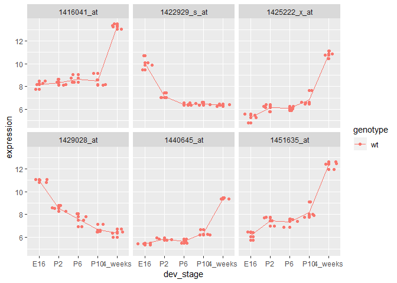

```r
ggplot(expressionDataForGene, aes(dev_stage, expression, color = genotype)) +
  geom_point() +
  geom_jitter() +
  stat_summary(aes(y = expression, group = 1), fun.y = mean, geom="line") +
  facet_wrap(~gene)
```

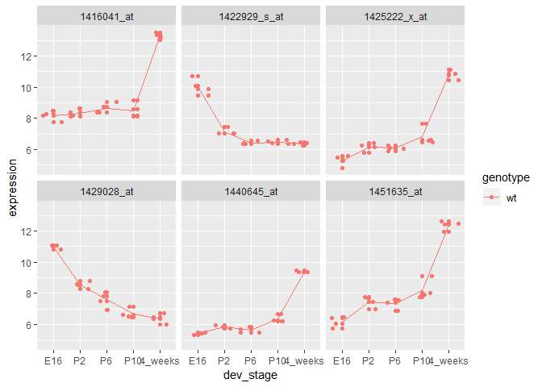

```r
# Make a function that filters to genes of interest and then reformats data and plots same as above (in "wt" only)
plotGenes <- function(geneIds, meltedExpressionMatrix, samplesMetadata){
  expressionDataForGene <- filter(meltedExpressionMatrix, gene %in% geneIds)
  expressionDataForGene <- select(expressionDataForGene, variable, gene, value) %>%
  rename(sample_id = variable, expression = value) %>%
  arrange(gene) %>%
  left_join(samplesMetadata, by = "sample_id") %>%
  filter(genotype == "wt")

  ggplot(expressionDataForGene, aes(dev_stage, expression, color = genotype)) +
  geom_point() +
  geom_jitter() +
  stat_summary(aes(y = expression, group = 1), fun.y = mean, geom="line") +
  facet_wrap(~gene)
}

plotGenes(geneIds, meltedExpressionMatrix, samplesMetadata) # check to make sure it works
```

### Plot probes that are not differentially expressed

```r
allGenes <- topTable(wildTypeDevStageFitEb, number = Inf)
```

```
## Removing intercept from test coefficients
```

```r
(boringGenes <- tail(allGenes))
```

```
##              dev_stageP2 dev_stageP6 dev_stageP10 dev_stage4_weeks AveExpr
## 1452600_at      -0.02575    -0.01750     -0.00575         -0.03150 6.20265
## 1416378_at       0.03650    -0.00075      0.01500         -0.00825 6.71775
## 1418235_at       0.00075    -0.00700      0.03500         -0.01500 6.44150
## 1431188_a_at     0.00575     0.02725      0.00875          0.00125 6.94585
## 1441195_at       0.01450     0.01400     -0.01475         -0.00750 7.68300
## 1436053_at      -0.00175    -0.00850     -0.00925         -0.00500 7.61335
##                        F   P.Value adj.P.Val
## 1452600_at   0.027650520 0.9983752 0.9985419
## 1416378_at   0.024051269 0.9987635 0.9988969
## 1418235_at   0.023367662 0.9988315 0.9989005
## 1431188_a_at 0.023344402 0.9988338 0.9989005
## 1441195_at   0.015007091 0.9995115 0.9995449
## 1436053_at   0.002772688 0.9999830 0.9999830
```

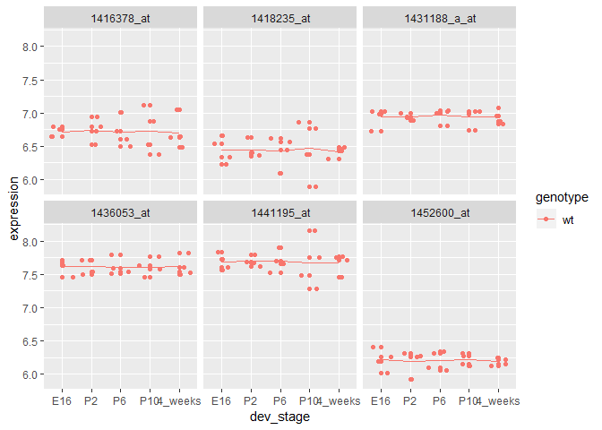

```r
geneIds <- rownames(boringGenes)

plotGenes(geneIds, meltedExpressionMatrix, samplesMetadata)
```

## Fit custom contrast matrix to limma model to compare different groups

```r
# make custom contrast matrix
contrastMatrix <- makeContrasts(
  p10vsp6 = dev_stageP10 - dev_stageP6,
  fourweeksVsP10 = dev_stage4_weeks - dev_stageP10,
  levels = designMatrix
) # function makeContrasts() allows you to compare desired groups, given an existing design matrix (levels = designMatrix)
contrastMatrix
```

```
##                   Contrasts
## Levels             p10vsp6 fourweeksVsP10
##   Intercept              0              0
##   dev_stageP2            0              0
##   dev_stageP6           -1              0
##   dev_stageP10           1             -1
##   dev_stage4_weeks       0              1
```

```r
# fit the contrasts using the original Limma model
contrastFit <- contrasts.fit(wildTypeDevStageFit, contrastMatrix) # function contrasts.fit() allows you to fit new contrasts to an existing lmFit() result, by providing a new contrast matrix generated with makeContrasts()
contrastFitEb <- eBayes(contrastFit)

contrastGenes <- topTable(contrastFitEb)

contrastGenes
```

```
##               p10vsp6 fourweeksVsP10 AveExpr        F      P.Value
## 1440645_at    0.72475        3.04125 6.52835 632.7410 2.224325e-17
## 1416041_at   -0.14700        4.78175 9.38250 302.3940 1.472973e-14
## 1425222_x_at  0.74925        3.98300 7.02815 235.3682 1.299509e-13
## 1424852_at    0.34425        3.40500 7.45405 225.1087 1.910320e-13
## 1420726_x_at  0.17325        3.55125 7.19000 203.5215 4.555385e-13
## 1451635_at    0.82600        4.17225 8.31860 200.0177 5.289072e-13
## 1429394_at   -0.09800        2.40975 7.84825 167.4991 2.416043e-12
## 1455447_at   -0.97650       -1.79975 9.97295 153.5444 5.063369e-12
## 1429791_at    0.24800        1.65825 8.02555 145.7407 7.877494e-12
## 1422612_at    0.48375        3.42600 8.83255 142.2388 9.676005e-12
##                 adj.P.Val
## 1440645_at   6.661631e-13
## 1416041_at   2.205703e-10
## 1425222_x_at 1.297300e-09
## 1424852_at   1.430304e-09
## 1420726_x_at 2.640040e-09
## 1451635_at   2.640040e-09
## 1429394_at   1.033687e-08
## 1455447_at   1.895536e-08
## 1429791_at   2.621367e-08
## 1422612_at   2.840295e-08
```

### Plot the top 6 differentially-expressed genes in the new limma result with 2 contrasts

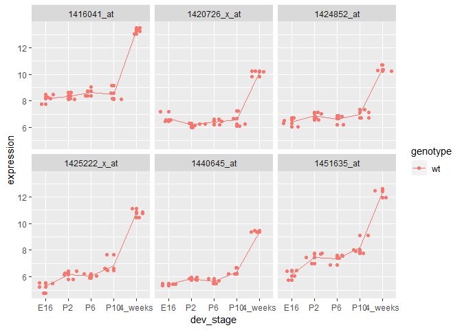

```r
plotGenes(rownames(contrastGenes[1:6,]), meltedExpressionMatrix, samplesMetadata)
```

> Note: All of these happen to be probes that are differentially expressed between 4-weeks and P10, but no difference between P10 and P6.

### Set p-value cutoff and identify probes that are differentially expressed desired contrast

```r
cutoff <- 1e-04
wtResCont <- decideTests(contrastFitEb, p.value = cutoff, method = "global") # function decideTests() identifies differentially expressed genes (at a given cutoff) between your contrasts (for a contrasts.fit() result); note, see later for use of this function on lmFit/eBayes result without contrasts.fit

summary(wtResCont) # function summary() when applied to decideTests() result gives you a count of all significantly up/down genes for each contrast
```

```
##        p10vsp6 fourweeksVsP10
## Down         4              8
## NotSig   29945          29895
## Up           0             46
```

> Note: Only 4 genes are differentially P10 vs. P6

#### Differential expression in P10 vs. P6

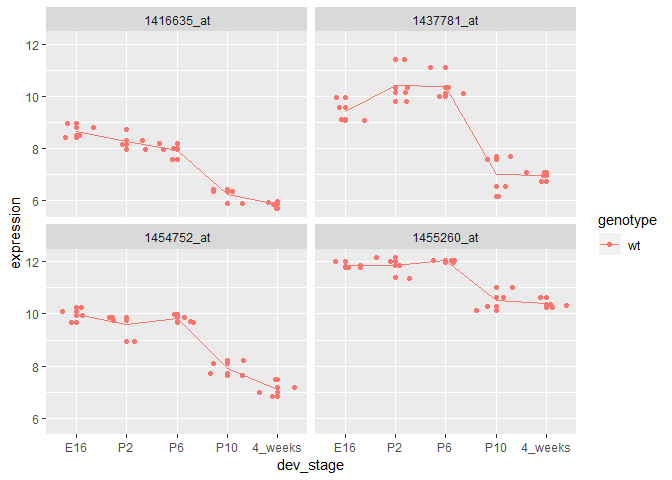

```r
hits1 <- as.data.frame(wtResCont) %>%
  rownames_to_column(var = "gene") %>%
  filter(p10vsp6 < 0)

plotGenes(geneIds = hits1$gene, meltedExpressionMatrix, samplesMetadata)
```

#### Selected differentially expressed genes in 4-weeks vs. P10 (4 downregulated)

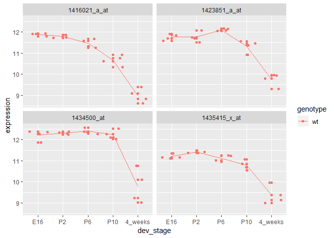

```r
hits2 <- as.data.frame(wtResCont) %>%
  rownames_to_column(var = "gene") %>%
  filter(fourweeksVsP10 < 0)

plotGenes(geneIds = hits2[1:4,]$gene, meltedExpressionMatrix, samplesMetadata)
```

## Assess interaction between genotype and developmental stage

First make simplified dataset considering the dev stages E16 & 4-weeks only:

```r
interactionSamples <- filter(samplesMetadata, dev_stage %in% c("E16", "4_weeks"))

# IMPORTANT - you want to adjust factor levels here to eliminate stages P2, P6, and P10 from your design matrix
interactionSamples$dev_stage <- interactionSamples$dev_stage %>%
  as.character() %>%
  factor(levels = c("E16", "4_weeks"))

interactionExpressionMatrix <- column_to_rownames(expressionMatrix, var = "gene") %>%
  select(interactionSamples$sample_id)
identical(colnames(interactionExpressionMatrix), interactionSamples$sample_id, attrib.as.set = T) # check to make sure the columns are in same order for metadata and expression matrix
```

```
## [1] TRUE
```

Make design matrix with interaction term:

```r
interactionDesign <- model.matrix(~genotype*dev_stage, interactionSamples)

interactionDesign # note that the intercept is still the E16 stage, since it is the first factor level
```

```
##    (Intercept) genotypeNrlKO dev_stage4_weeks
## 1            1             0                0
## 2            1             0                0
## 3            1             0                0
## 4            1             0                0
## 5            1             1                0
## 6            1             1                0
## 7            1             1                0
## 8            1             0                1
## 9            1             0                1
## 10           1             0                1
## 11           1             0                1
## 12           1             1                1
## 13           1             1                1
## 14           1             1                1
```

[output cut: 25 more lines]

Run limma with interaction design matrix:

```r
interactionFit <- lmFit(interactionExpressionMatrix, interactionDesign)
interactionFitEb <- eBayes(interactionFit)

interactionAll <- topTable(interactionFitEb, number = Inf)
```

```
## Removing intercept from test coefficients
```

```r
head(interactionAll, 10)
```

```
##              genotypeNrlKO dev_stage4_weeks genotypeNrlKO.dev_stage4_weeks
## 1451618_at      0.21608333          6.28825                    -6.13208333
## 1451617_at      0.28408333          6.68475                    -6.87433333
## 1460212_at      0.30625000          5.79325                    -5.76250000
## 1425171_at      0.01225000          6.07875                    -5.81475000
## 1421061_at      0.29183333          6.05350                     0.10316667
## 1455098_a_at   -0.14075000          5.49325                    -0.49700000
## 1458418_at     -0.04500000          6.34650                    -5.91725000
## 1451590_at     -0.26083333          4.95400                    -0.03166667
## 1451647_at     -0.05983333          5.79850                    -5.21666667
## 1420484_a_at   -0.01158333          5.02575                    -0.55591667
##               AveExpr        F      P.Value    adj.P.Val
## 1451618_at   8.283600 879.3647 1.664656e-16 4.985479e-12
## 1451617_at   7.699867 753.4162 5.018679e-16 5.260441e-12
## 1460212_at   9.232733 745.2092 5.426619e-16 5.260441e-12
## 1425171_at   8.235867 718.7119 7.025865e-16 5.260441e-12
## 1421061_at   9.513733 667.2588 1.193317e-15 7.147728e-12
## 1455098_a_at 7.778267 554.4248 4.465675e-15 2.229042e-11
## 1458418_at   6.986867 525.0126 6.581959e-15 2.816044e-11
## 1451590_at   9.485467 475.8156 1.325023e-14 4.960391e-11
## 1451647_at   7.775000 435.6206 2.480441e-14 8.254079e-11
## 1420484_a_at 8.796000 417.5622 3.350105e-14 1.003323e-10
```

Find genes with interaction between genotype and dev_stage:

```r
interactionGenes <- decideTests(object = interactionFitEb, p.value = 1e-06, method = "global") # function decideTests() can also be used to identify significant results from a standard lmFit/eBayes result

summary(interactionGenes)
```

```
##        (Intercept) genotypeNrlKO dev_stage4_weeks
## Down             0             1               39
## NotSig           0         29948            29642
## Up           29949             0              268
##        genotypeNrlKO:dev_stage4_weeks
## Down                               28
## NotSig                          29904
## Up                                 17
```

Look for down regulation across developmental stages in wt but up regulation in genotypeNrlKO:

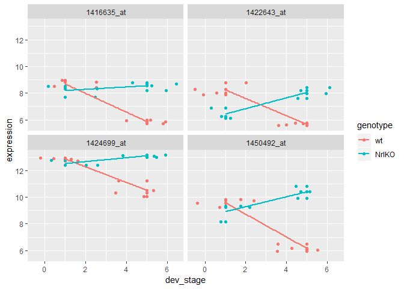

```r
geneIds <- as.data.frame(interactionGenes) %>%
  rownames_to_column(var = "gene") %>%
  filter(dev_stage4_weeks < 0, `genotypeNrlKO:dev_stage4_weeks` > 0) %>% # this selects genes that are downregulated at 4 weeks in the 1st-level genotype (wt), but that go up in the alternative genotype at 4 weeks
  select(gene) %>% unlist()

# tweak the plotGenes function for this new task
plotGenes2 <- function(geneIds, meltedExpressionMatrix, samplesMetadata){
  expressionDataForGene <- filter(meltedExpressionMatrix, gene %in% geneIds)
  expressionDataForGene <- select(expressionDataForGene, variable, gene, value) %>%
  rename(sample_id = variable, expression = value) %>%
  arrange(gene) %>%
  left_join(samplesMetadata, by = "sample_id") %>%
  filter(dev_stage %in% c("E16", "4_weeks"))

  expressionDataForGene$dev_stage <- expressionDataForGene$dev_stage %>% as.numeric() # this is necessary to get geom_smooth to work

  ggplot(expressionDataForGene, aes(dev_stage, expression, color = genotype)) +
  geom_point() +
  geom_jitter() +
    geom_smooth(method = "lm", se = F) +
  facet_wrap(~gene)
}

plotGenes2(geneIds[1:4], meltedExpressionMatrix, samplesMetadata)
```

# Deliverable

Make a similar plot but this time for 4 genes where there is no interaction between genotype and developmental stages.

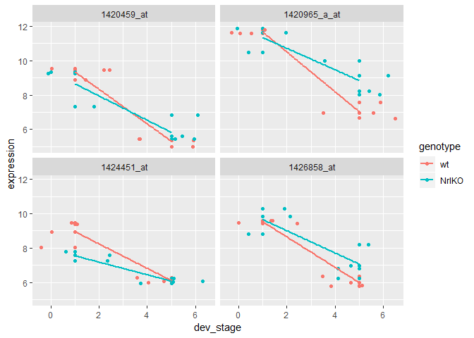

```r
geneIds <- as.data.frame(interactionGenes) %>%
  rownames_to_column(var = "gene") %>%
  filter(dev_stage4_weeks < 0, `genotypeNrlKO:dev_stage4_weeks` == 0) %>%
  select(gene) %>% unlist()

plotGenes2(geneIds[5:8], meltedExpressionMatrix, samplesMetadata)
```